# WoLKE-Studie-2026

Author

Benedikt Beuttler

Published

March 6, 2026

```r
if (FALSE) {
  install.packages("renv") #1
  renv::restore() #2
}
```

# 1 Preamble

## 1.1 Prepare the Environment

## 1.2 Load Libraries

```r
# install pacman
if (!requireNamespace("pacman", quietly = TRUE)) {
  install.packages("pacman")
}
library(pacman)

## Pfad/Utilities
p_load(this.path)

## Wrangling
# use pacman to load packages
p_load(dplyr, tidyr, stringr, forcats, purrr, magrittr)

## Ähnlichkeit/Text
p_load(stringdist, psych)

## Modellierung
p_load(lavaan, lme4, lmerTest, emmeans, estimatr)

## Tabellen/Reporting
# install.packages("remotes")

# remotes::install_version(
#   "modelsummary",
#   version = "2.5.0",
#   repos = "https://cran.r-project.org"
# )

p_load(modelsummary)
p_load(kableExtra, arsenal)

## Visualisierung/Themes
p_load(ggplot2, ggsci, jtools)

p_load(mnormt)

source(file = "functions.r") # all outsourced funtions
```

```r
is_word <- !(knitr::is_html_output() | knitr::is_latex_output())

if (is_word) {
  p_load(flextable)
}
```

## 1.3 Load Pre- and Posttest and Reshape Data

```r
#define vars
controls <- c("gender", "semester", "location")
random_terms_lmer <- c("(1 | code)")
groups <- c("intervention")
time <- "time"
outcomes <- c(
  "AILIT",
  "AILIThorn",
  "AILITglat",
  "TK",
  "TPK",
  "TCK",
  "TPACKce",
  "TPACKgenai",
  "Ethics",
  "CEA",
  "CEA_understanding",
  "CEA_ped"
)
vars_num <- c("age", "semester") # numeric outcomes
vars_cat <- c("gender", "students") # categorical outcomes`
```

```r
prepare_data <- FALSE
if (prepare_data) {
  # Set working directory to the script's location
  # safe working-directory selection (replace setwd(this.path::this.dir()))
  wd <- tryCatch(this.path::this.dir(), error = function(e) NULL)

  if (is.null(wd)) {
    wd <- tryCatch(
      {
        if (
          requireNamespace("rstudioapi", quietly = TRUE) &&
            rstudioapi::isAvailable()
        ) {
          dirname(rstudioapi::getActiveDocumentContext()$path)
        } else if (requireNamespace("here", quietly = TRUE)) {
          here::here()
        } else {
          getwd()
        }
      },
      error = function(e) getwd()
    )
  }
  setwd(normalizePath(wd))

  # execute load_prepare_data.r to load and prepare the data via source command
  suppressMessages(source("./data/load_prepare_data.r"))
} else {
  # load pre-prepared data
  load("data/26-data_all.Rdata") # nicht nach pre und posttest gefiltert
  load("data/26-data.Rdata") # probanden mit pre UND posttest
  # load all Rdata from folder /data/dropouts
  files <- list.files("data/dropouts", pattern = "\\.Rdata$", full.names = TRUE)
  invisible(lapply(files, load, envir = .GlobalEnv))
}

data_pre <- data %>% filter(time == "pre")
```

```r
### grouping scales
## TPACK
# all TPACK items used
list_items_i_tpack <- list(
  "TK" = grep("^TP01_", names(data), value = T),
  "TPK" = grep("^TP02_", names(data), value = T),
  "TCK" = grep("^TP03_", names(data), value = T),
  "TPACK_ce" = grep("^TP04_(0[1-8]|12|15)$", names(data), value = T), # Sub-Subskala 1: Celik Enhanced Items
  "TPACK_genai" = grep("^TP04_(09|10|11|13|14)$", names(data), value = T), # Sub-Subskala 2: GenAI Items
  "Ethics" = grep("^TP05_0[1-6]$", names(data), value = T) #im pretest nur items 1-6 vorhanden 7,8 kamen im post dazu
)

# ein paar ethik items müssen noch rausgenommen werden, die nur im posttest erhoben wurden. hier nur check
# data_subset1 <- data %>% select(all_of(unlist(list_items_i_tpack)))
# View(data_subset1)

## Critical Evaluation of AI
list_items_cea <- list(
  "CEA" = grep("^RE02_(0[1-9])$", names(data), value = T),
  "CEA_understanding" = grep("^RE02_(0[1-4])$", names(data), value = T),
  "CEA_ped" = grep("^RE02_(0[5-9])$", names(data), value = T)
)
# data_subset3 <- data %>% select(all_of(unlist(list_items_cea)))
# sum(data_subset3 < 0, na.rm = TRUE)

## AI Literacy
# data <- data %>% mutate(AILIT = AI35_02) # rename to sumscore
list_items_ailit <- list(
  "ailit" = grep(
    "^(AI36_04|AI36_10|AI36_11|AI36_13|AI36_15|AI36_16|AI36_17|AI36_19|AI36_24|AI36_25|AI36_27|GL21_01|GL21_02|GL21_03|GL21_04|GL21_05|GL21_06|GL21_07|GL21_08|GL21_09|GL21_10|GL21_11|GL21_12|GL21_13|GL21_14|GL21_15|GL21_16|GL21_17|GL21_18|GL21_19)", # results of all ailit items
    names(data),
    value = T
  ),
  "ailit_horn" = grep(
    "^(AI36_04|AI36_10|AI36_11|AI36_13|AI36_15|AI36_16|AI36_17|AI36_19|AI36_24|AI36_25|AI36_27)",
    names(data),
    value = T
  ), # Hornberger items
  "ailit_glat" = grep(
    "^(GL21_01|GL21_02|GL21_03|GL21_04|GL21_05|GL21_06|GL21_07|GL21_08|GL21_09|GL21_10|GL21_11|GL21_12|GL21_13|GL21_14|GL21_15|GL21_16|GL21_17|GL21_18|GL21_19)",
    names(data),
    value = T
  ) # GLAT items
)

# create new columns with the means of the lists
data <- data %>%
  mutate(
    AILIT = rowSums(cbind(AI35_02, GL20_01), na.rm = TRUE), # default sumscore overall AI Lit
    AILIThorn = rowSums(
      select(., all_of(list_items_ailit$ailit_horn)),
      na.rm = TRUE
    ),
    AILITglat = rowSums(
      select(., all_of(list_items_ailit$ailit_glat)),
      na.rm = TRUE
    ),
    TK = rowMeans(select(., all_of(list_items_i_tpack$TK)), na.rm = TRUE),
    TPK = rowMeans(select(., all_of(list_items_i_tpack$TPK)), na.rm = TRUE),
    TCK = rowMeans(select(., all_of(list_items_i_tpack$TCK)), na.rm = TRUE),
    TPACKce = rowMeans(
      select(., all_of(list_items_i_tpack$TPACK_ce)),
      na.rm = TRUE
    ),
    TPACKgenai = rowMeans(
      select(., all_of(list_items_i_tpack$TPACK_genai)),
      na.rm = TRUE
    ),
    Ethics = rowMeans(
      select(., all_of(list_items_i_tpack$Ethics)),
      na.rm = TRUE
    ),
    CEA = rowMeans(select(., all_of(list_items_cea$CEA)), na.rm = TRUE),
    CEA_understanding = rowMeans(
      select(., all_of(list_items_cea$CEA_understanding)),
      na.rm = TRUE
    ),
    CEA_ped = rowMeans(select(., all_of(list_items_cea$CEA_ped)), na.rm = TRUE),
    TPACK_total = rowMeans(
      select(., all_of(unlist(list_items_i_tpack))),
      na.rm = TRUE
    )
  )

# check missing values in TPACK and PU scales (NA means, not answered (-1 diff. answer, -9 not answered))
data %>%
  select(all_of(c(list_items_i_tpack) %>% unlist)) %>%
  summarise(across(everything(), ~ sum(is.na(.x)))) %>%
  sum # 0
```

```
[1] 0
```

```r
# reshape to long
data_long <- data %>%
  pivot_longer(
    cols = c(all_of(outcomes)),
    names_to = "outcome",
    values_to = "score"
  )

data_long <- data_long %>%
  mutate(
    outcome = factor(outcome, levels = outcomes)
  )
```

```r
# TPACK
p_tpack <- plot_outcome(
  data_long %>% filter(!str_detect(outcome, "^(AILIT|CEA)")),
  scales_facet = "fixed"
) +
  ggtitle("Intelligent-TPACK")

ggsave(
  p_tpack + facet_wrap(~outcome, ncol = 3),
  file = "figures/plot-tpack.pdf",
  width = 8,
  height = 10,
  device = cairo_pdf
)
# AILIT
p_ailit <- plot_outcome(
  data_long %>% filter(str_detect(outcome, "^(AILIT)"))
) +
  ggtitle("AI Literacy")

# Critical Evaluation of AI
p_cea <- plot_outcome(
  data_long %>% filter(str_detect(outcome, "^(CEA)"))
) +
  ggtitle("Critical Evaluation of AI (CEA)")
```

# 2 Methods

## 2.1 Participants

```r
p_load(dplyr, tidyr) # needs to be called for rendering to work

data_participants <- data %>%
  filter(time == "pre") %>%
  group_by(intervention, location, gender) %>%
  summarise(
    n = n(),
    n_complete = sum(complete.cases(.)),
    age_min = min(age, na.rm = T),
    age_max = max(age, na.rm = T),
    age_mean = mean(age, na.rm = T) %>% round(2),
    age_sd = sd(age, na.rm = T) %>% round(2),
    semester_min = min(semester, na.rm = T),
    semester_max = max(semester, na.rm = T),
    semester_mean = mean(semester, na.rm = T) %>% round(2),
    semester_sd = sd(semester, na.rm = T) %>% round(2),
    .groups = "drop"
  )
```

```r
# render as table
format <- ifelse(
  knitr::is_html_output(),
  "markdown",
  ifelse(knitr::is_latex_output(), "latex", "markdown")
)

var_names <- list(
  gender = "Gender",
  age = "Age",
  semester = "Semester Number",
  students = "Study Level",
  isp = "Completed Integrated Semester Internship",
  subject1 = "Subject 1",
  subject2 = "Subject 2",
  studies = "Study Program",
  location = "University",
  TK = "Intelligent TK",
  TCK = "Intelligent TCK",
  TPK = "Intelligent TPK",
  TPACK_total = "Intelligent TPACK",
  AILIT = "AI Literacy",
  Ethics = "AI Ethics",
  CEA = "Critical Evaluation of AI"
)

kable(
  summary(
    tableby(
      intervention ~
        location +
        age +
        gender +
        semester +
        students +
        TK +
        TCK +
        TPK +
        TPACK_total +
        Ethics +
        AILIT +
        CEA,
      data %>%
        filter(time == "pre") %>%
        mutate(
          students = factor(students, labels = c("Bachelor", "Master"))
        ) %>%
        droplevels(),
      cat.test = "chisq",
      chisq.correct = T,
      control = tableby.control(test = T, total = T, digits = 2)
    ),
    labelTranslations = var_names,
    pfootnote = T,
    text = F
  ),
  escape = T,
  format = format,
  booktabs = T
)
```

Table 1: Demographic Data of the Three Experimental Groups.

|  | control (N=55) | stem (N=15) | language (N=22) | Total (N=92) | p value |
| --- | --- | --- | --- | --- | --- |
| **University** |  |  |  |  | < 0.001<sup>1</sup> |
| PH Ludwigsburg | 54 (98.2%) | 8 (53.3%) | 22 (100.0%) | 84 (91.3%) |  |
| PH Schwäbisch Gmünd | 1 (1.8%) | 7 (46.7%) | 0 (0.0%) | 8 (8.7%) |  |
| **Age** |  |  |  |  | 0.214<sup>2</sup> |
| Mean (SD) | 24.62 (2.51) | 26.53 (7.43) | 24.77 (2.64) | 24.97 (3.78) |  |
| Range | 21.00 - 34.00 | 23.00 - 53.00 | 21.00 - 31.00 | 21.00 - 53.00 |  |
| **Gender** |  |  |  |  | 0.003<sup>1</sup> |
| Female | 40 (72.7%) | 8 (53.3%) | 22 (100.0%) | 70 (76.1%) |  |
| Male | 15 (27.3%) | 7 (46.7%) | 0 (0.0%) | 22 (23.9%) |  |
| **Semester Number** |  |  |  |  | 0.527<sup>2</sup> |
| Mean (SD) | 9.16 (2.52) | 9.60 (2.20) | 8.73 (1.80) | 9.13 (2.31) |  |
| Range | 3.00 - 20.00 | 6.00 - 14.00 | 6.00 - 12.00 | 3.00 - 20.00 |  |
| **Study Level** |  |  |  |  | 0.590<sup>1</sup> |
| Bachelor | 7 (12.7%) | 1 (6.7%) | 4 (18.2%) | 12 (13.0%) |  |
| Master | 48 (87.3%) | 14 (93.3%) | 18 (81.8%) | 80 (87.0%) |  |
| **Intelligent TK** |  |  |  |  | 0.761<sup>2</sup> |
| Mean (SD) | 3.43 (0.78) | 3.39 (0.78) | 3.55 (0.73) | 3.45 (0.76) |  |
| Range | 2.00 - 5.00 | 2.00 - 5.00 | 2.00 - 4.80 | 2.00 - 5.00 |  |
| **Intelligent TCK** |  |  |  |  | 0.543<sup>2</sup> |
| Mean (SD) | 2.87 (0.77) | 3.08 (0.57) | 3.02 (0.89) | 2.94 (0.77) |  |
| Range | 1.00 - 5.00 | 2.00 - 4.40 | 1.80 - 4.80 | 1.00 - 5.00 |  |
| **Intelligent TPK** |  |  |  |  | 0.678<sup>2</sup> |
| Mean (SD) | 2.67 (0.72) | 2.83 (0.94) | 2.59 (0.91) | 2.68 (0.80) |  |
| Range | 1.00 - 4.14 | 1.43 - 4.86 | 1.00 - 4.57 | 1.00 - 4.86 |  |
| **Intelligent TPACK** |  |  |  |  | 0.688<sup>2</sup> |
| Mean (SD) | 2.66 (0.66) | 2.83 (0.75) | 2.67 (0.72) | 2.69 (0.69) |  |
| Range | 1.26 - 4.39 | 1.66 - 4.74 | 1.50 - 3.95 | 1.26 - 4.74 |  |
| **AI Ethics** |  |  |  |  | 0.703<sup>2</sup> |
| Mean (SD) | 2.52 (0.78) | 2.63 (0.73) | 2.42 (0.68) | 2.52 (0.74) |  |
| Range | 1.00 - 4.33 | 1.50 - 4.17 | 1.17 - 3.50 | 1.00 - 4.33 |  |
| **AI Literacy** |  |  |  |  | 0.033<sup>2</sup> |
| Mean (SD) | 16.49 (4.98) | 20.13 (6.57) | 16.50 (2.63) | 17.09 (4.98) |  |
| Range | 7.00 - 29.00 | 4.00 - 29.00 | 11.00 - 24.00 | 4.00 - 29.00 |  |
| **Critical Evaluation of AI** |  |  |  |  | 0.322<sup>2</sup> |
| Mean (SD) | 3.49 (0.71) | 3.72 (0.60) | 3.70 (0.68) | 3.58 (0.69) |  |
| Range | 1.78 - 4.67 | 2.33 - 4.78 | 2.56 - 5.00 | 1.78 - 5.00 |  |

## 2.2 Materials

### 2.2.1 Data Preparation and Cleaning (needs to be done after data gets merged)

```r
# get participants who only participated in pre or post test
data_dropouts <- data_all %>%
  group_by(code) %>%
  summarise(
    has_pre = any(time == "pre"),
    has_post = any(time == "post"),
    .groups = "drop"
  ) %>%
  summarise(
    n_pre_only = sum(has_pre & !has_post),
    n_post_only = sum(!has_pre & has_post),
    n_both = sum(has_pre & has_post)
  )
```

## 2.3 Statistical Analysis Ancova

```r
# reshape data to wide format for ancova
data_wide <- data %>%
  pivot_wider(
    id_cols = c(
      code,
      intervention,
      group,
      gender,
      semester,
      students,
      location
    ),
    names_from = time,
    values_from = all_of(outcomes)
  ) %>%
  mutate(
    # scale the posttest score so that the estimates are approximations of Cohen's d
    across(all_of(outcomes %>% paste0("_post")), scale),
    treatment = factor(ifelse(
      intervention == "control",
      "control",
      "intervention"
    ))
  )

contrasts.treatment <- cbind(c(-1 / 2, 1 / 2))
colnames(contrasts.treatment) <- c("-c+t")
contrasts(data_wide$treatment) <- contrasts.treatment

ancovas <- lapply(
  outcomes,
  fit_ancova,
  groups,
  # we remove University as a covariate as we only have control students at University 2
  setdiff(controls, "location"),
  "HC3",
  data_wide
)
names(ancovas) <- outcomes

ancovas_two_groups <- lapply(
  outcomes,
  fit_ancova,
  "treatment",
  setdiff(controls, "location"),
  "HC3",
  data_wide
)
names(ancovas_two_groups) <- outcomes
```

## 2.4 AI Literacy

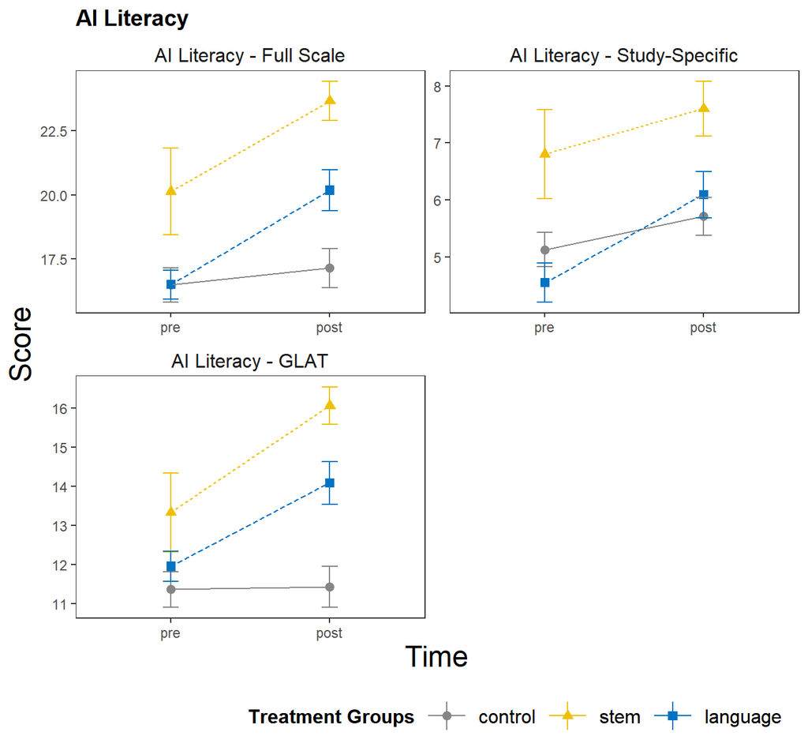

Figure 1: Descriptive Statistics of Students’ AI Literacy Scores Over Time by Treatment Group.

```r
ft_ailit_ancova <- modelsummary_models(
  ancovas[names(ancovas) %in% c("AILIT", "AILIThorn", "AILITglat")],
  outcomes = c("AILIT", "AILIThorn", "AILITglat"),
  output = modelsummary_output
) # %>%   kableExtra::scroll_box(width = "100%")

if (is_word) {
  ft_ailit_ancova <- adjust_table_for_word(ft_ailit_ancova, width = .75)
}
ft_ailit_ancova
```

Table 2: Summary of Multiple Regression Models for AI Literacy.

|  | AILIT b | AILIT SE | AILIT t | AILIT p | AILIThorn b | AILIThorn SE | AILIThorn t | AILIThorn p | AILITglat b | AILITglat SE | AILITglat t | AILITglat p |
| --- | --- | --- | --- | --- | --- | --- | --- | --- | --- | --- | --- | --- |
| (Intercept) | -2.03*** | 0.42 | -4.81 | <0.001 | -1.71*** | 0.44 | -3.93 | <0.001 | -1.78*** | 0.39 | -4.62 | <0.001 |
| interventionstem | 0.92*** | 0.21 | 4.38 | <0.001 | 0.49* | 0.23 | 2.10 | 0.039 | 1.05*** | 0.22 | 4.70 | <0.001 |
| interventionlanguage | 0.56* | 0.22 | 2.58 | 0.012 | 0.33 | 0.23 | 1.39 | 0.168 | 0.61** | 0.22 | 2.73 | 0.008 |
| pretest | 0.07* | 0.03 | 2.63 | 0.010 | 0.16*** | 0.05 | 3.59 | <0.001 | 0.10* | 0.04 | 2.49 | 0.015 |
| genderMale | -0.07 | 0.19 | -0.36 | 0.716 | 0.13 | 0.22 | 0.60 | 0.547 | -0.18 | 0.20 | -0.90 | 0.372 |
| semester | 0.06 | 0.05 | 1.10 | 0.276 | 0.07 | 0.05 | 1.58 | 0.118 | 0.04 | 0.05 | 0.81 | 0.422 |
| Num.Obs. | 92 |  |  |  | 92 |  |  |  | 92 |  |  |  |
| R2 | 0.360 |  |  |  | 0.275 |  |  |  | 0.345 |  |  |  |
| R2 Adj. | 0.322 |  |  |  | 0.233 |  |  |  | 0.307 |  |  |  |
| AIC | 233.1 |  |  |  | 244.5 |  |  |  | 235.1 |  |  |  |
| BIC | 250.7 |  |  |  | 262.1 |  |  |  | 252.8 |  |  |  |
| RMSE | 0.80 |  |  |  | 0.85 |  |  |  | 0.80 |  |  |  |

AILIT_post ~ intervention + pretest + gender + semester

interventionstem = Unterschied zwischen STEM und CONTROL

interventionlanguage = Unterschied zwischen Language und CONTROL

Das Modell testet nicht direkt STEM vs Language.

b interessiert und hier und ob der Wert sign (*) ist oder nicht.

| Outcome | STEM Effekt | Language Effekt |
| --- | --- | --- |
| AILIT | **0.92*** | **0.56*** |
| AILIThorn | **0.49*** | n.s. |
| AILITglat | **1.05*** | **0.61** |

```r
if (!is_word) {
  cat("### Pairwise Contrasts Between Groups")
}
```

### 2.4.1 Pairwise Contrasts Between Groups

```r
# pairwise between contrasts (no multiplicity adjustment)
ailit_ancova_between_contrasts <- lapply(ancovas[1:3], function(m) {
  emmeans(m, ~intervention) %>%
    contrast(interaction = "pairwise", adjust = "none")
})
if (!is_word) {
  print(ailit_ancova_between_contrasts)
}
```

```
$AILIT
 intervention_pairwise estimate    SE df t.ratio p.value
 control - stem          -0.924 0.211 86  -4.382 <0.0001
 control - language      -0.563 0.219 86  -2.576  0.0117
 stem - language          0.361 0.231 86   1.563  0.1217

Results are averaged over the levels of: gender

$AILIThorn
 intervention_pairwise estimate    SE df t.ratio p.value
 control - stem          -0.485 0.231 86  -2.098  0.0388
 control - language      -0.327 0.235 86  -1.391  0.1677
 stem - language          0.159 0.287 86   0.553  0.5817

Results are averaged over the levels of: gender

$AILITglat
 intervention_pairwise estimate    SE df t.ratio p.value
 control - stem          -1.053 0.224 86  -4.703 <0.0001
 control - language      -0.613 0.224 86  -2.732  0.0076
 stem - language          0.440 0.243 86   1.809  0.0739

Results are averaged over the levels of: gender
```

## 2.5 Intelligent TPACK and AI Ethics

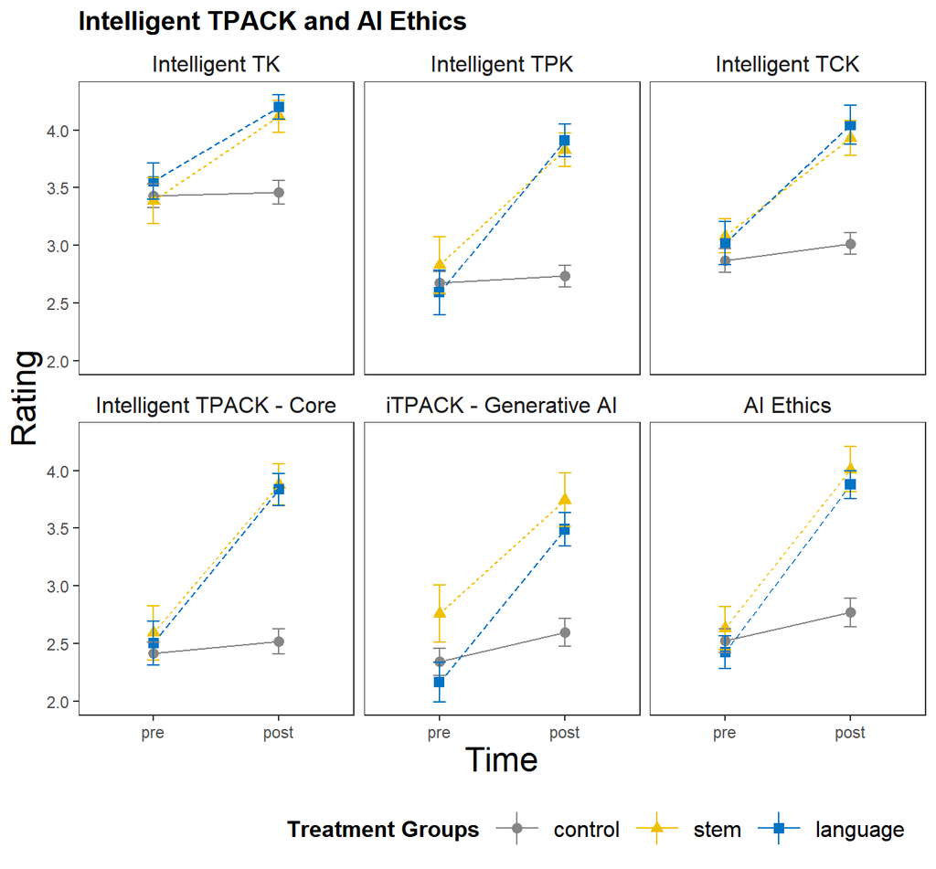

Figure 2: Descriptive Statistics of Students’ Intelligent TPACK and AI Ethics Ratings Over Time by Treatment Group.

```r
ft_ancova <- modelsummary_models(
  ancovas[grepl("^(T|Ethics)", names(ancovas))],
  outcomes = outcomes %>% grep("^(T|Ethics)", ., value = TRUE),
  output = modelsummary_output,
) # %>%   kableExtra::scroll_box(width = "100%")

if (is_word) {
  ft_ancova <- adjust_table_for_word(ft_ancova, width = 1)
}
ft_ancova
```

Table 3: Summary of Multiple Regression Models for Intelligent TPACK Subscales and AI Ethics

|  | TK b | TK SE | TK t | TK p | TPK b | TPK SE | TPK t | TPK p | TCK b | TCK SE | TCK t | TCK p | TPACKce b | TPACKce SE | TPACKce t | TPACKce p | TPACKgenai b | TPACKgenai SE | TPACKgenai t | TPACKgenai p | Ethics b | Ethics SE | Ethics t | Ethics p |
| --- | --- | --- | --- | --- | --- | --- | --- | --- | --- | --- | --- | --- | --- | --- | --- | --- | --- | --- | --- | --- | --- | --- | --- | --- |
| (Intercept) | -3.19*** | 0.52 | -6.16 | <0.001 | -2.07*** | 0.39 | -5.29 | <0.001 | -2.23*** | 0.40 | -5.61 | <0.001 | -2.04*** | 0.42 | -4.87 | <0.001 | -1.39** | 0.46 | -3.04 | 0.003 | -1.96*** | 0.43 | -4.53 | <0.001 |
| interventionstem | 0.94*** | 0.21 | 4.48 | <0.001 | 1.18*** | 0.20 | 5.92 | <0.001 | 0.92*** | 0.20 | 4.64 | <0.001 | 1.25*** | 0.22 | 5.59 | <0.001 | 0.94*** | 0.27 | 3.46 | <0.001 | 1.21*** | 0.28 | 4.35 | <0.001 |
| interventionlanguage | 0.84*** | 0.16 | 5.33 | <0.001 | 1.39*** | 0.19 | 7.14 | <0.001 | 1.16*** | 0.23 | 5.04 | <0.001 | 1.28*** | 0.17 | 7.62 | <0.001 | 1.06*** | 0.20 | 5.33 | <0.001 | 1.15*** | 0.17 | 6.83 | <0.001 |
| pretest | 0.81*** | 0.11 | 7.49 | <0.001 | 0.46*** | 0.11 | 4.36 | <0.001 | 0.61*** | 0.10 | 6.03 | <0.001 | 0.54*** | 0.08 | 6.33 | <0.001 | 0.50*** | 0.09 | 5.53 | <0.001 | 0.56*** | 0.11 | 5.11 | <0.001 |
| genderMale | -0.18 | 0.21 | -0.87 | 0.385 | -0.04 | 0.19 | -0.23 | 0.817 | 0.17 | 0.16 | 1.03 | 0.306 | 0.02 | 0.19 | 0.10 | 0.918 | 0.23 | 0.21 | 1.10 | 0.273 | -0.12 | 0.23 | -0.54 | 0.593 |
| semester | 0.01 | 0.04 | 0.21 | 0.833 | 0.04 | 0.03 | 1.06 | 0.292 | -0.00 | 0.04 | -0.04 | 0.967 | 0.02 | 0.04 | 0.54 | 0.591 | -0.03 | 0.05 | -0.64 | 0.525 | 0.01 | 0.04 | 0.32 | 0.753 |
| Num.Obs. | 92 |  |  |  | 92 |  |  |  | 92 |  |  |  | 92 |  |  |  | 92 |  |  |  | 92 |  |  |  |
| R2 | 0.578 |  |  |  | 0.568 |  |  |  | 0.554 |  |  |  | 0.633 |  |  |  | 0.476 |  |  |  | 0.503 |  |  |  |
| R2 Adj. | 0.553 |  |  |  | 0.543 |  |  |  | 0.528 |  |  |  | 0.612 |  |  |  | 0.446 |  |  |  | 0.474 |  |  |  |
| AIC | 194.7 |  |  |  | 196.8 |  |  |  | 199.8 |  |  |  | 181.9 |  |  |  | 214.6 |  |  |  | 209.7 |  |  |  |
| BIC | 212.4 |  |  |  | 214.5 |  |  |  | 217.4 |  |  |  | 199.5 |  |  |  | 232.3 |  |  |  | 227.4 |  |  |  |
| RMSE | 0.65 |  |  |  | 0.65 |  |  |  | 0.66 |  |  |  | 0.60 |  |  |  | 0.72 |  |  |  | 0.70 |  |  |  |

## 2.6 Critical Evaluation of AI (CEA)

Note für uns: ggf. reduzieren wir CEA auf eine Skala mit 9 Items. Im Piloten haben wir 15 items getestet und EFA hat gezeigt, dass Reduktion auf 2 Skalen möglich wäre. Das haben wir gemacht, und die funktionieren auch, aber ein Item lädt z.B. ziemlich stark auf die andere Skala. Entweder bekommt man das gut begründet, aber den richtigen Mehrwert sehe ich nicht, 2 Skalen aufzustellen. So oder so, es haben alle Skalen gut funktioniert und zeigen den Mehrwert vom Seminar.

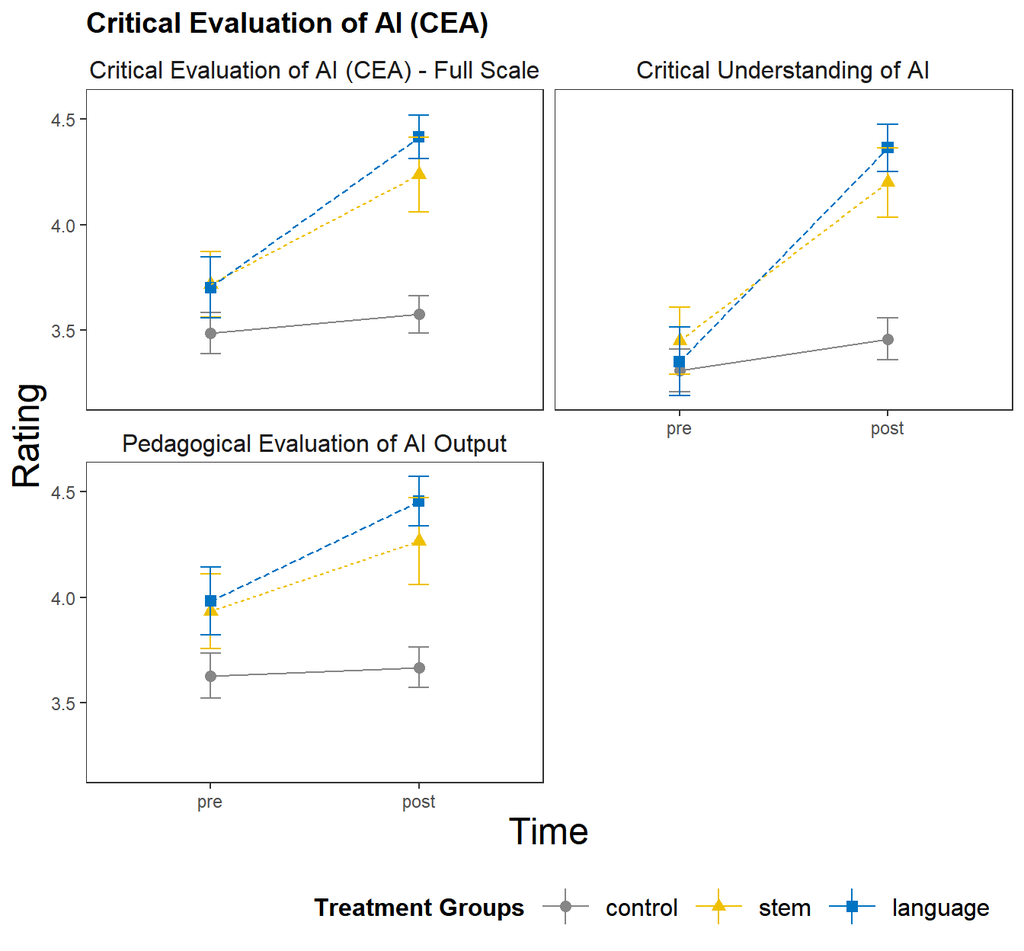

Figure 3: Descriptive Statistics of Students’ Critical Evaluation of AI Over Time by Treatment Group.

```r
ft_cea_ancova <- modelsummary_models(
  ancovas[grepl("^(CEA)", names(ancovas))],
  outcomes = c("CEA", "CEA_understanding", "CEA_ped"),
  output = modelsummary_output,
) # %>%   kableExtra::scroll_box(width = "100%")

if (is_word) {
  ft_cea_ancova <- adjust_table_for_word(ft_cea_ancova, width = .75)
}
ft_cea_ancova
```

Table 4: Summary of Multiple Regression Models for CEA subscale.

|  | CEA b | CEA SE | CEA t | CEA p | CEA_understanding b | CEA_understanding SE | CEA_understanding t | CEA_understanding p | CEA_ped b | CEA_ped SE | CEA_ped t | CEA_ped p |
| --- | --- | --- | --- | --- | --- | --- | --- | --- | --- | --- | --- | --- |
| (Intercept) | -3.11*** | 0.54 | -5.75 | <0.001 | -2.71*** | 0.46 | -5.83 | <0.001 | -2.83*** | 0.63 | -4.52 | <0.001 |
| interventionstem | 0.72** | 0.27 | 2.64 | 0.010 | 0.83** | 0.25 | 3.28 | 0.001 | 0.55+ | 0.28 | 1.95 | 0.055 |
| interventionlanguage | 1.01*** | 0.17 | 5.93 | <0.001 | 1.14*** | 0.19 | 5.96 | <0.001 | 0.79*** | 0.18 | 4.51 | <0.001 |
| pretest | 0.75*** | 0.12 | 6.15 | <0.001 | 0.61*** | 0.11 | 5.53 | <0.001 | 0.70*** | 0.13 | 5.28 | <0.001 |
| genderMale | 0.06 | 0.22 | 0.25 | 0.800 | 0.04 | 0.20 | 0.19 | 0.850 | 0.08 | 0.24 | 0.32 | 0.750 |
| semester | 0.01 | 0.04 | 0.16 | 0.871 | 0.03 | 0.03 | 0.85 | 0.396 | -0.01 | 0.04 | -0.21 | 0.835 |
| Num.Obs. | 92 |  |  |  | 92 |  |  |  | 92 |  |  |  |
| R2 | 0.540 |  |  |  | 0.486 |  |  |  | 0.486 |  |  |  |
| R2 Adj. | 0.514 |  |  |  | 0.456 |  |  |  | 0.456 |  |  |  |
| AIC | 202.6 |  |  |  | 212.8 |  |  |  | 212.8 |  |  |  |
| BIC | 220.2 |  |  |  | 230.4 |  |  |  | 230.4 |  |  |  |
| RMSE | 0.67 |  |  |  | 0.71 |  |  |  | 0.71 |  |  |  |

```r
# cronbach alpha
alphas <- imap(
  list_items_cea,
  ~ psych::alpha(dplyr::select(data_pre, dplyr::all_of(.x)), warnings = FALSE)
)
alphas
```

```
$CEA

Reliability analysis
Call: psych::alpha(x = dplyr::select(data_pre, dplyr::all_of(.x)),
    warnings = FALSE)

  raw_alpha std.alpha G6(smc) average_r S/N   ase mean   sd median_r
      0.86      0.86    0.89      0.41 6.1 0.023  3.6 0.69      0.4

    95% confidence boundaries
         lower alpha upper
Feldt     0.81  0.86   0.9
Duhachek  0.81  0.86   0.9

 Reliability if an item is dropped:
        raw_alpha std.alpha G6(smc) average_r S/N alpha se var.r med.r
RE02_01      0.83      0.83    0.87      0.39 5.1    0.027 0.033  0.34
RE02_02      0.85      0.85    0.88      0.42 5.8    0.024 0.035  0.43
RE02_03      0.85      0.86    0.88      0.43 6.0    0.024 0.028  0.41
RE02_04      0.86      0.86    0.89      0.44 6.3    0.023 0.026  0.43
RE02_05      0.85      0.86    0.89      0.43 5.9    0.024 0.031  0.43
RE02_06      0.83      0.84    0.87      0.39 5.1    0.027 0.026  0.38
RE02_07      0.83      0.83    0.86      0.38 4.9    0.028 0.025  0.38
RE02_08      0.83      0.83    0.86      0.38 5.0    0.027 0.024  0.38
RE02_09      0.84      0.84    0.87      0.40 5.3    0.026 0.035  0.36

 Item statistics
         n raw.r std.r r.cor r.drop mean   sd
RE02_01 92  0.77  0.77  0.74   0.70  3.4 0.95
RE02_02 92  0.63  0.62  0.55   0.50  3.3 1.13
RE02_03 92  0.60  0.59  0.53   0.47  2.8 1.02
RE02_04 92  0.53  0.53  0.45   0.40  3.9 1.00
RE02_05 92  0.61  0.60  0.52   0.48  3.2 1.14
RE02_06 92  0.76  0.77  0.76   0.68  4.2 0.97
RE02_07 92  0.79  0.80  0.81   0.72  4.1 0.96
RE02_08 92  0.78  0.79  0.79   0.70  4.1 0.97
RE02_09 92  0.71  0.72  0.68   0.62  3.3 0.96

Non missing response frequency for each item
           1    2    3    4    5 miss
```

[output cut: 67 more lines]

```
 Item statistics
         n raw.r std.r r.cor r.drop mean   sd
RE02_05 92  0.60  0.57  0.40   0.36  3.2 1.14
RE02_06 92  0.81  0.82  0.79   0.68  4.2 0.97
RE02_07 92  0.86  0.87  0.88   0.78  4.1 0.96
RE02_08 92  0.86  0.87  0.87   0.77  4.1 0.97
RE02_09 92  0.75  0.75  0.66   0.61  3.3 0.96

Non missing response frequency for each item
           1    2    3    4    5 miss
RE02_05 0.07 0.25 0.24 0.33 0.12    0
RE02_06 0.01 0.07 0.14 0.33 0.46    0
RE02_07 0.01 0.05 0.18 0.34 0.41    0
RE02_08 0.01 0.07 0.15 0.35 0.42    0
RE02_09 0.03 0.16 0.39 0.32 0.10    0
```

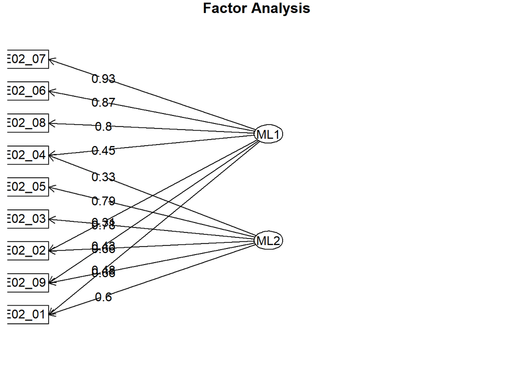

```r
# 0.86 alpha, kein item lohnt sich rauszunehmen

data_post <- data %>% filter(time == "post" & CEA != "NaN")
# EFA
ncomp <- 2
# EFA
df_cea_items <- data_post %>%
  select(all_of(list_items_cea$CEA)) %>%
  na.omit()
cea_scale <- list_items_cea %>% unlist(use.names = F)

efa_promax <- df_cea_items %>%
  select(any_of(cea_scale)) %>%
  psych::fa(nfactors = ncomp, rotate = "varimax", fm = "ml", missing = T)

# print(efa_promax, digits = 2, cut = .3, sort = F)
fa.diagram(efa_promax, digits = 2, cut = .30, simple = FALSE)
```

```r
## Computing EFA using the lavaan package
cea_efa <- lavaan::efa(
  df_cea_items %>%
    select(any_of(cea_scale)),
  nfactors = ncomp,
  rotation = "varimax",
  ordered = F,
  std.lv = TRUE,
  missing = "fiml"
)

summary(cea_efa, nd = 3L, cutoff = 0.3, dot.cutoff = 0.05)
```

```
  Estimator                                         ML
  Rotation method                   VARIMAX ORTHOGONAL
  Rotation algorithm (rstarts)                GPA (30)
  Standardized metric                             TRUE
  Row weights                                   Kaiser

  Number of observations                            92
  Number of missing patterns                         1

Fit measures:
                    aic      bic    sabic  chisq df pvalue   cfi rmsea
  nfactors = 2 1866.465 1954.728 1844.248 29.229 19  0.062 0.982 0.079

Eigenvalues correlation matrix:

    ev1     ev2     ev3     ev4     ev5     ev6     ev7     ev8     ev9
  4.986   1.394   0.746   0.554   0.381   0.330   0.268   0.217   0.124

Standardized loadings: (* = significant at 1% level)

            f1      f2       unique.var   communalities
RE02_01  0.604*  0.479*           0.406           0.594
RE02_02  0.656*  0.306*           0.476           0.524
RE02_03  0.783*      .            0.383           0.617
RE02_04  0.328*  0.445*           0.694           0.306
RE02_05  0.787*      .*           0.319           0.681
RE02_06      .*  0.873*           0.193           0.807
RE02_07      .*  0.925*           0.080           0.920
RE02_08      .*  0.797*           0.310           0.690
RE02_09  0.656*  0.425*           0.389           0.611

                              f2    f1 total
Sum of sq (ortho) loadings 3.018 2.732 5.750
Proportion of total        0.525 0.475 1.000
Proportion var             0.335 0.304 0.639
Cumulative var             0.335 0.639 0.639
```

Results from efa and cronbachs alpha confirm our exploration and adjustments from pilot data. we have a good scale in CEA.

## 2.7 Two Groups (Control vs. Intervention)

```r
modelsummary_models(
  ancovas_two_groups,
  outcomes = outcomes,
  output = modelsummary_output
)
```

Table 5: Summary of Multiple Linear Regression Models for Two Treatment Groups.

|  | AILIT b | AILIT SE | AILIT t | AILIT p | AILIThorn b | AILIThorn SE | AILIThorn t | AILIThorn p | AILITglat b | AILITglat SE | AILITglat t | AILITglat p | TK b | TK SE | TK t | TK p | TPK b | TPK SE | TPK t | TPK p | TCK b | TCK SE | TCK t | TCK p | TPACKce b | TPACKce SE | TPACKce t | TPACKce p | TPACKgenai b | … |
| --- | --- | --- | --- | --- | --- | --- | --- | --- | --- | --- | --- | --- | --- | --- | --- | --- | --- | --- | --- | --- | --- | --- | --- | --- | --- | --- | --- | --- | --- | --- |
| (Intercept) | -1.77*** | 0.40 | -4.41 | <0.001 | -1.55*** | 0.40 | -3.88 | <0.001 | -1.48*** | 0.39 | -3.84 | <0.001 | -2.74*** | 0.51 | -5.40 | <0.001 | -1.39*** | 0.39 | -3.56 | <0.001 | -1.68*** | 0.40 | -4.22 | <0.001 | -1.41** | 0.42 | -3.32 | 0.001 | -0.87+ | … |
| treatment-c+t | 0.71*** | 0.18 | 3.84 | <0.001 | 0.39* | 0.18 | 2.13 | 0.036 | 0.80*** | 0.19 | 4.13 | <0.001 | 0.88*** | 0.14 | 6.42 | <0.001 | 1.30*** | 0.15 | 8.52 | <0.001 | 1.06*** | 0.17 | 6.38 | <0.001 | 1.27*** | 0.14 | 8.84 | <0.001 | 1.01*** | … |
| pretest | 0.08** | 0.03 | 2.82 | 0.006 | 0.17*** | 0.04 | 4.00 | <0.001 | 0.10* | 0.04 | 2.60 | 0.011 | 0.80*** | 0.11 | 7.55 | <0.001 | 0.46*** | 0.11 | 4.35 | <0.001 | 0.61*** | 0.10 | 6.10 | <0.001 | 0.54*** | 0.08 | 6.39 | <0.001 | 0.50*** | … |
| genderMale | 0.01 | 0.18 | 0.07 | 0.941 | 0.17 | 0.21 | 0.80 | 0.428 | -0.08 | 0.18 | -0.42 | 0.675 | -0.15 | 0.19 | -0.83 | 0.409 | -0.10 | 0.18 | -0.52 | 0.603 | 0.11 | 0.16 | 0.64 | 0.522 | 0.01 | 0.18 | 0.06 | 0.950 | 0.21 | … |
| semester | 0.06 | 0.05 | 1.13 | 0.263 | 0.07 | 0.05 | 1.62 | 0.108 | 0.04 | 0.05 | 0.85 | 0.396 | 0.01 | 0.04 | 0.24 | 0.809 | 0.03 | 0.03 | 1.00 | 0.319 | -0.00 | 0.04 | -0.09 | 0.925 | 0.02 | 0.04 | 0.54 | 0.590 | -0.03 | … |
| Num.Obs. | 92 |  |  |  | 92 |  |  |  | 92 |  |  |  | 92 |  |  |  | 92 |  |  |  | 92 |  |  |  | 92 |  |  |  | 92 | … |
| R2 | 0.349 |  |  |  | 0.273 |  |  |  | 0.329 |  |  |  | 0.577 |  |  |  | 0.564 |  |  |  | 0.549 |  |  |  | 0.633 |  |  |  | 0.475 | … |
| R2 Adj. | 0.319 |  |  |  | 0.240 |  |  |  | 0.298 |  |  |  | 0.558 |  |  |  | 0.544 |  |  |  | 0.528 |  |  |  | 0.616 |  |  |  | 0.451 | … |
| AIC | 232.6 |  |  |  | 242.7 |  |  |  | 235.4 |  |  |  | 192.9 |  |  |  | 195.7 |  |  |  | 198.8 |  |  |  | 179.9 |  |  |  | 212.8 | … |
| BIC | 247.7 |  |  |  | 257.9 |  |  |  | 250.5 |  |  |  | 208.1 |  |  |  | 210.8 |  |  |  | 214.0 |  |  |  | 195.0 |  |  |  | 228.0 | … |
| RMSE | 0.80 |  |  |  | 0.85 |  |  |  | 0.81 |  |  |  | 0.65 |  |  |  | 0.66 |  |  |  | 0.67 |  |  |  | 0.60 |  |  |  | 0.72 | … |

```r
# save environment
save.image("data/26-env-analysis.Rdata")
```